# Credit Card Fraud Detection

Praditya Humam Ramadhanu

11/11/2020

# Introduction

Project ini bertujuan untuk membuat model yang dapat mengklasifikasikan apakah sebuah transaksi termasuk fraud atau tidak. Kebanyakan fitur dalam dataset sudah discaled nilainya dan tidak ditunjukkan nama fiturnya untuk alasan privasi. Namun,kita tetap bisa membangun model menggunakan fitur-fitur tersebut untuk melakukan klasifikasi.

## Tujuan Project

1. Memahami distribusi data transaksi yang bersifat fraud dan tidak.
2. Membuat sub-dataframe dengan rasio transaksi fraud dan tidak fraud yang tidak terlalu jauh agar model tidak overfitting.
3. Menentukan algoritma klasifikasi mana yang memberikan hasil yang terbaik.

## Referensi

1. [Kaggle](https://www.kaggle.com/janiobachmann/credit-fraud-dealing-with-imbalanced-datasets/notebook)
2. [Machinelearningplus.com](https://www.machinelearningplus.com/machine-learning/caret-package/)
3. Data Science with R by Andre Olesky (2018)

## Packages yang Digunakan

```r
# library untuk mengolah data
library(utils)
library(tidyr)
library(dplyr)
```

```r
# library untuk memplot data
library(corrplot)
library(ggplot2)

# library untuk membangun model
library(caret)
# library untuk directory
library(here)
```

# Datasets

Dataset transaksi kartu kredit berasal dari [kaggle](https://www.kaggle.com/mlg-ulb/creditcardfraud). Data berisi 28 variabel yang tidak diketahui nama kolomnya dan sudah di scaled oleh pemilik data,variabel waktu transaksi, dan variabel jumlah uang pertransaksi.

```r
# Import data csv
df <- read.csv(here("creditcard.csv"))

# melihat ringkasan dataframe
str(df)
```

```
## 'data.frame':    284807 obs. of  31 variables:
##  $ Time  : num  0 0 1 1 2 2 4 7 7 9 ...
##  $ V1    : num  -1.36 1.192 -1.358 -0.966 -1.158 ...
##  $ V2    : num  -0.0728 0.2662 -1.3402 -0.1852 0.8777 ...
##  $ V3    : num  2.536 0.166 1.773 1.793 1.549 ...
##  $ V4    : num  1.378 0.448 0.38 -0.863 0.403 ...
##  $ V5    : num  -0.3383 0.06 -0.5032 -0.0103 -0.4072 ...
##  $ V6    : num  0.4624 -0.0824 1.8005 1.2472 0.0959 ...
##  $ V7    : num  0.2396 -0.0788 0.7915 0.2376 0.5929 ...
##  $ V8    : num  0.0987 0.0851 0.2477 0.3774 -0.2705 ...
##  $ V9    : num  0.364 -0.255 -1.515 -1.387 0.818 ...
##  $ V10   : num  0.0908 -0.167 0.2076 -0.055 0.7531 ...
##  $ V11   : num  -0.552 1.613 0.625 -0.226 -0.823 ...
##  $ V12   : num  -0.6178 1.0652 0.0661 0.1782 0.5382 ...
##  $ V13   : num  -0.991 0.489 0.717 0.508 1.346 ...
```

[output cut: 17 more lines]

```r
summary(df)
```

```
##       Time              V1                  V2                  V3
##  Min.   :     0   Min.   :-56.40751   Min.   :-72.71573   Min.   :-48.3256
##  1st Qu.: 54202   1st Qu.: -0.92037   1st Qu.: -0.59855   1st Qu.: -0.8904
##  Median : 84692   Median :  0.01811   Median :  0.06549   Median :  0.1799
##  Mean   : 94814   Mean   :  0.00000   Mean   :  0.00000   Mean   :  0.0000
##  3rd Qu.:139321   3rd Qu.:  1.31564   3rd Qu.:  0.80372   3rd Qu.:  1.0272
##  Max.   :172792   Max.   :  2.45493   Max.   : 22.05773   Max.   :  9.3826
##        V4                 V5                   V6                 V7
##  Min.   :-5.68317   Min.   :-113.74331   Min.   :-26.1605   Min.   :-43.5572
##  1st Qu.:-0.84864   1st Qu.:  -0.69160   1st Qu.: -0.7683   1st Qu.: -0.5541
##  Median :-0.01985   Median :  -0.05434   Median : -0.2742   Median :  0.0401
##  Mean   : 0.00000   Mean   :   0.00000   Mean   :  0.0000   Mean   :  0.0000
##  3rd Qu.: 0.74334   3rd Qu.:   0.61193   3rd Qu.:  0.3986   3rd Qu.:  0.5704
##  Max.   :16.87534   Max.   :  34.80167   Max.   : 73.3016   Max.   :120.5895
##        V8                  V9                 V10                 V11
##  Min.   :-73.21672   Min.   :-13.43407   Min.   :-24.58826   Min.   :-4.79747
##  1st Qu.: -0.20863   1st Qu.: -0.64310   1st Qu.: -0.53543   1st Qu.:-0.76249
##  Median :  0.02236   Median : -0.05143   Median : -0.09292   Median :-0.03276
##  Mean   :  0.00000   Mean   :  0.00000   Mean   :  0.00000   Mean   : 0.00000
##  3rd Qu.:  0.32735   3rd Qu.:  0.59714   3rd Qu.:  0.45392   3rd Qu.: 0.73959
##  Max.   : 20.00721   Max.   : 15.59500   Max.   : 23.74514   Max.   :12.01891
##       V12                V13                V14                V15
##  Min.   :-18.6837   Min.   :-5.79188   Min.   :-19.2143   Min.   :-4.49894
##  1st Qu.: -0.4056   1st Qu.:-0.64854   1st Qu.: -0.4256   1st Qu.:-0.58288
##  Median :  0.1400   Median :-0.01357   Median :  0.0506   Median : 0.04807
##  Mean   :  0.0000   Mean   : 0.00000   Mean   :  0.0000   Mean   : 0.00000
##  3rd Qu.:  0.6182   3rd Qu.: 0.66251   3rd Qu.:  0.4931   3rd Qu.: 0.64882
##  Max.   :  7.8484   Max.   : 7.12688   Max.   : 10.5268   Max.   : 8.87774
##       V16                 V17                 V18
##  Min.   :-14.12985   Min.   :-25.16280   Min.   :-9.498746
##  1st Qu.: -0.46804   1st Qu.: -0.48375   1st Qu.:-0.498850
##  Median :  0.06641   Median : -0.06568   Median :-0.003636
##  Mean   :  0.00000   Mean   :  0.00000   Mean   : 0.000000
##  3rd Qu.:  0.52330   3rd Qu.:  0.39968   3rd Qu.: 0.500807
##  Max.   : 17.31511   Max.   :  9.25353   Max.   : 5.041069
##       V19                 V20                 V21
##  Min.   :-7.213527   Min.   :-54.49772   Min.   :-34.83038
##  1st Qu.:-0.456299   1st Qu.: -0.21172   1st Qu.: -0.22839
##  Median : 0.003735   Median : -0.06248   Median : -0.02945
##  Mean   : 0.000000   Mean   :  0.00000   Mean   :  0.00000
```

[output cut: 8 more lines]

```
##  Max.   : 10.503090   Max.   : 22.52841   Max.   : 4.58455
##       V25                 V26                V27
##  Min.   :-10.29540   Min.   :-2.60455   Min.   :-22.565679
##  1st Qu.: -0.31715   1st Qu.:-0.32698   1st Qu.: -0.070840
##  Median :  0.01659   Median :-0.05214   Median :  0.001342
##  Mean   :  0.00000   Mean   : 0.00000   Mean   :  0.000000
##  3rd Qu.:  0.35072   3rd Qu.: 0.24095   3rd Qu.:  0.091045
##  Max.   :  7.51959   Max.   : 3.51735   Max.   : 31.612198
##       V28                Amount             Class
##  Min.   :-15.43008   Min.   :    0.00   Min.   :0.000000
##  1st Qu.: -0.05296   1st Qu.:    5.60   1st Qu.:0.000000
##  Median :  0.01124   Median :   22.00   Median :0.000000
##  Mean   :  0.00000   Mean   :   88.35   Mean   :0.001728
##  3rd Qu.:  0.07828   3rd Qu.:   77.17   3rd Qu.:0.000000
##  Max.   : 33.84781   Max.   :25691.16   Max.   :1.000000
```

```r
# cek jumlah data kosong dan data na
sum(is.null(df))
```

```
## [1] 0
```

```r
sum(is.na(df))
```

```
## [1] 0
```

```r
# melihat perbandingan data fraud dan non frauds
p_f <- round(sum(df$Class==1)/nrow(df)*100,2)
p_nf <- round(sum(df$Class==0)/nrow(df)*100,2)
sprintf("Persentase data yang bersifat frauds adalah %g persen",p_f)
```

```
## [1] "Persentase data yang bersifat frauds adalah 0.17 persen"
```

```r
sprintf("Persentase data yang bersifat non-frauds adalah %g persen",p_nf)
```

```
## [1] "Persentase data yang bersifat non-frauds adalah 99.83 persen"
```

### Exploration Data Analysis

Berdasarkan eksplorasi data diatas, tidak terdapat nilai NULL atau nilai NA pada dataset. Dataset juga sangat tidak seimbang, persentase observasi yang termasuk non-frauds jauh lebih besar dibandingkan yang termasuk frauds.

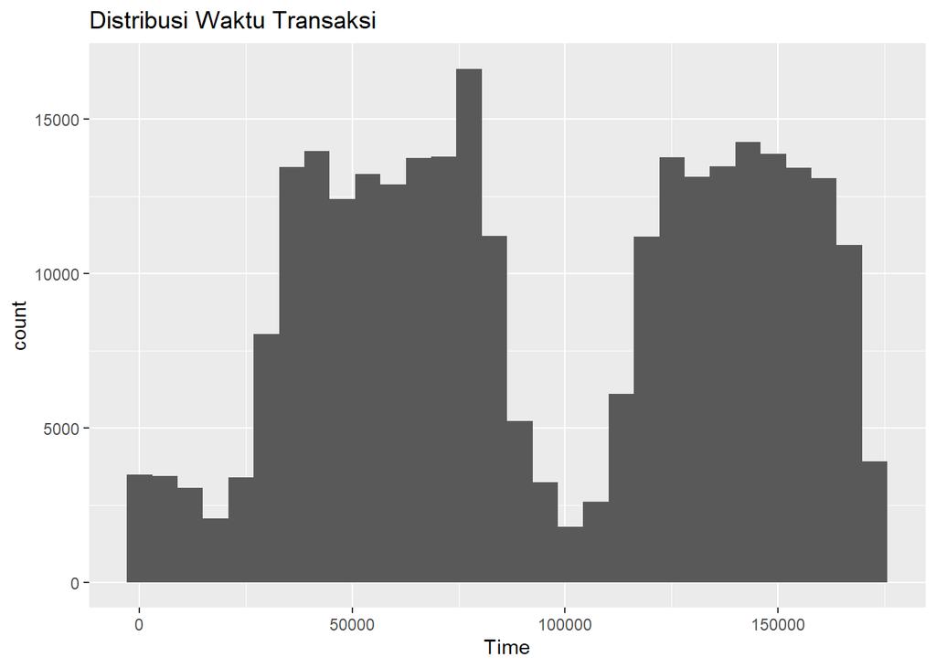

```r
#memplot distribusi waktu dan jumlah per transaksi
ggplot(df,aes(x=Time))+
  geom_histogram()+
  labs(title = "Distribusi Waktu Transaksi")
```

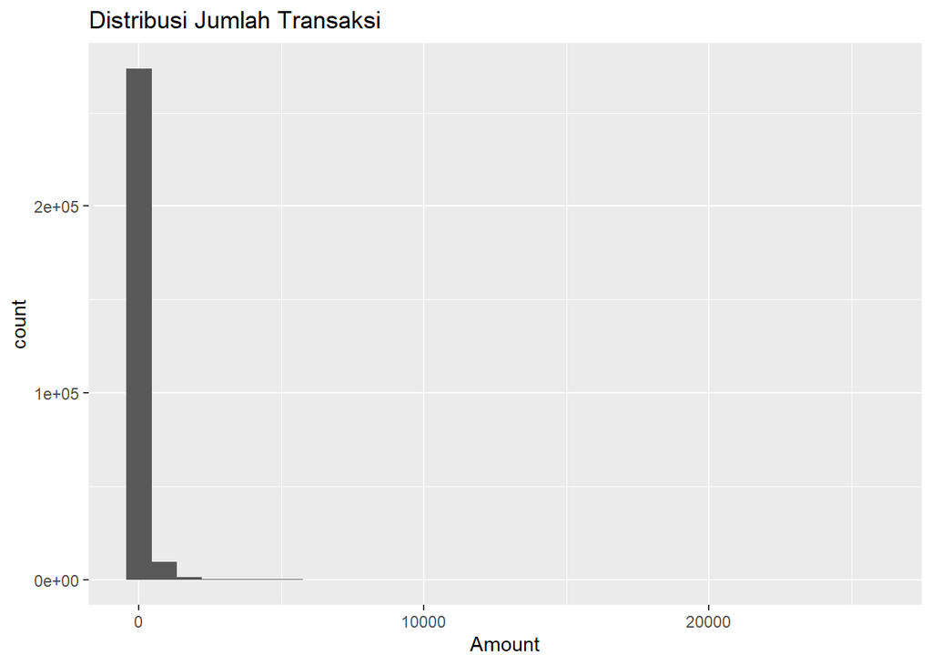

```r
ggplot(df,aes(x=Amount))+
  geom_histogram()+
  labs(title ="Distribusi Jumlah Transaksi")
```

Dilihat dari distribusi waktu transaksi diketahui bahwa terdapat dua waktu puncak yang terjadi jumlah transaksi terbanyak. Dilihat dari distribusi jumlah transaksi diketahui bahwa jumlah transaksi di dataset ini mayoritas adalah transaksi berjumlah kecil.

#Pre-processing

### Scaling Variabel

Semua variabel kecuali “Time” dan “Amount” sudah di scaled, oleh karena itu kita scaled variebel “Time” dan “Amount”.

```r
#membuat dataset baru tanpa kolom time dan amount untuk sampling
new_df<- subset(df,select = -c(Time,Amount))

#membuat skala kolom time dan amount agar ternormalisasi di dataset baru
new_df$scale_time <- scale(df$Time)
new_df$scale_amount <- scale(df$Amount)
```

### Undersampling

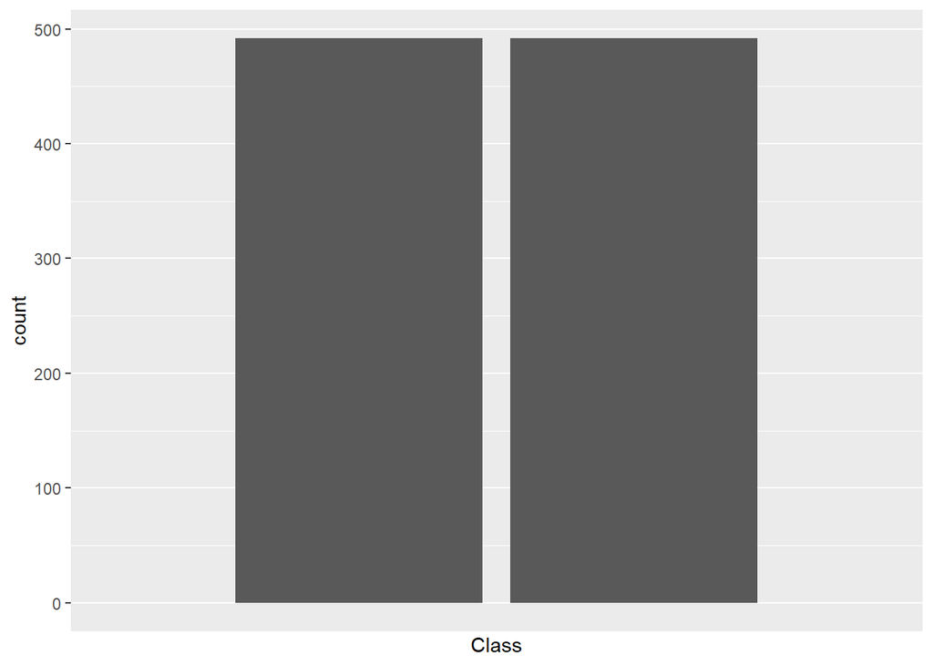

```r
#membuat dataset baru tanpa kolom time dan amount untuk sampling
data<- subset(df,select = -c(Time,Amount))

#membuat skala kolom time dan amount agar ternormalisasi di dataset baru
data$scale_time <- scale(df$Time)
data$scale_amount <- scale(df$Amount)

#membuat dataset baru untuk yang fraud dan non fraud
fraud_df <- filter(data,Class==1)
nfraud_df <- filter(data,Class==0)

#Melakukan undersampling
set.seed(50)
sample_num <- sample(nrow(nfraud_df),nrow(fraud_df))
under_sampling <- nfraud_df[sample_num,]

#membuat dataset baru hasil undersampling
new_df <- rbind(fraud_df,under_sampling)

#plot hasil undersampling
ggplot(new_df,aes(x=Class))+
  geom_bar()+
  scale_x_discrete(labels=c('non-fraud','fraud'))
```

### Correlation Matrix

Setelah semua data di scaled, kita lihat bagimana korelasi antar semua variabel dengan memplot correlation matrix.

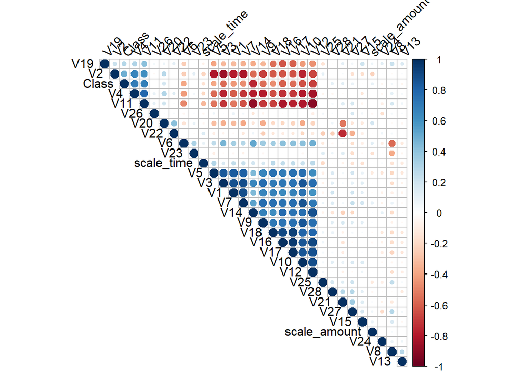

```r
#melihat korelasi matrix antar variabel
cor_mat <- cor(new_df)
corrplot(cor_mat, type = "upper", order = "hclust",
         tl.col = "black", tl.srt = 45)
```

```r
#Melihat mana yang korelasi paling berpengaruh ke Class
matrix <- cor_mat[,"Class"]

# 5 korelasi positif tertinggi terhadap variabel Class
print(tail(sort(matrix),5,decreasing=TRUE))
```

```
##       V19        V2       V11        V4     Class
## 0.2862293 0.4867436 0.6846938 0.6952337 1.0000000
```

```r
# 5 korelasi negatif tertinggi terhadap variabel Class
print(head(sort(matrix),5,decreasing=TRUE))
```

```
##        V14        V12        V10        V16         V3
## -0.7533102 -0.6819162 -0.6319585 -0.5941377 -0.5671144
```

Dari correlation matrix diatas didapatkan variabel yang paling berpengaruh terhadap variabel “Class” adalah V14,V4,V11,V12, dan V10.

### Outlier Removal

Selanjutnya kita menghilangkan data-data outlier data-data outlier berdasarkan V14,V4,V11,V12, dan V10. Namun, karena label yang diutamakan untuk dideteksi adalah berlabel fraud, maka kita lebih mengutamakan menghapus nilai outlier dari data-data yang berlabel fraud.

```r
#menghapus data outlier berdasarkan v14,v4,v11,v12,v10

##Mendapatkan nilai yg fraud di V14
v14_fraud <- new_df%>%
  filter(Class==1)


v14_q25 <- quantile(v14_fraud$V14,0.25)
sprintf("kuartil 25 v14 adalah %g",v14_q25)
```

```
## [1] "kuartil 25 v14 adalah -9.69272"
```

```r
v14_q75 <- quantile(v14_fraud$V14,0.75)
sprintf("kuartil 75 v14 adalah %g",v14_q75)
```

```
## [1] "kuartil 75 v14 adalah -4.28282"
```

```r
v14_iqr <- v14_q75 - v14_q25
sprintf("Jarak Interkuartil v14 adalah %g",v14_iqr)
```

```
## [1] "Jarak Interkuartil v14 adalah 5.4099"
```

```r
v14_upper <- v14_q75 + v14_iqr*1.5
sprintf("V14 Upper : %g",v14_upper)
```

```
## [1] "V14 Upper : 3.83203"
```

```r
v14_lower <- v14_q25 - v14_iqr*1.5
sprintf("V14 Lower : %g",v14_lower)
```

```
## [1] "V14 Lower : -17.8076"
```

```r
outlier_v14 <- which(v14_fraud$V14<v14_lower|v14_fraud$V14>v14_upper)
data_outlier_v14 <- v14_fraud[outlier_v14,"V14"]
print(data_outlier_v14)
```

```
## [1] -19.21433 -18.82209 -18.49377 -18.05000
```

```r
length(data_outlier_v14)
```

```
## [1] 4
```

```r
#menghilangkan data outlier dari dataset
if(length(outlier_v14)>0){
  new_df <- new_df[-outlier_v14,]
} else print("Tidak ada data outlier")


##Mendapatkan nilai yg fraud di V4
v4_fraud <- new_df%>%
  filter(Class==1)


v4_q25 <- quantile(v4_fraud$V4,0.25)
sprintf("kuartil 25 v4 adalah %g",v4_q25)
```

```
## [1] "kuartil 25 v4 adalah 2.35158"
```

```r
v4_q75 <- quantile(v4_fraud$V4,0.75)
sprintf("kuartil 75 v4 adalah %g",v4_q75)
```

```
## [1] "kuartil 75 v4 adalah 6.31302"
```

```r
v4_iqr <- v4_q75 - v4_q25
sprintf("Jarak Interkuartil v4 adalah %g",v4_iqr)
```

```
## [1] "Jarak Interkuartil v4 adalah 3.96143"
```

```r
v4_upper <- v4_q75 + v4_iqr*1.5
sprintf("V4 Upper : %g",v4_upper)
```

```
## [1] "V4 Upper : 12.2552"
```

```r
v4_lower <- v4_q25 - v4_iqr*1.5
sprintf("V4 Lower : %g",v4_lower)
```

```
## [1] "V4 Lower : -3.59057"
```

```r
outlier_v4 <- which(v4_fraud$V4<v4_lower|v4_fraud$V4>v4_upper)
data_outlier_v4 <- v4_fraud[outlier_v4,"V4"]
print(data_outlier_v4)
```

```
## numeric(0)
```

```r
length(data_outlier_v4)
```

```
## [1] 0
```

```r
#menghilangkan data outlier dari dataset
if(length(outlier_v4)>0){
  new_df <- new_df[-outlier_v4,]
} else print("Tidak ada data outlier")
```

```
## [1] "Tidak ada data outlier"
```

```r
##Mendapatkan nilai yg fraud di V11
v11_fraud <- new_df%>%
  filter(Class==1)


v11_q25 <- quantile(v11_fraud$V11,0.25)
sprintf("kuartil 25 v11 adalah %g",v11_q25)
```

```
## [1] "kuartil 25 v11 adalah 1.96515"
```

```r
v11_q75 <- quantile(v11_fraud$V11,0.75)
sprintf("kuartil 75 v11 adalah %g",v11_q75)
```

```
## [1] "kuartil 75 v11 adalah 5.2669"
```

```r
v11_iqr <- v11_q75 - v11_q25
sprintf("Jarak Interkuartil v11 adalah %g",v11_iqr)
```

```
## [1] "Jarak Interkuartil v11 adalah 3.30175"
```

```r
v11_upper <- v11_q75 + v11_iqr*1.5
sprintf("V11 Upper : %g",v11_upper)
```

```
## [1] "V11 Upper : 10.2195"
```

```r
v11_lower <- v11_q25 - v11_iqr*1.5
sprintf("V11 Lower : %g",v11_lower)
```

```
## [1] "V11 Lower : -2.98748"
```

```r
outlier_v11 <- which(v11_fraud$V11<v11_lower|v11_fraud$V11>v11_upper)
data_outlier_v11 <- v11_fraud[outlier_v11,"V11"]
print(data_outlier_v11)
```

```
## [1] 10.85301 10.44685 11.27792 11.15249 11.02706 10.54526 10.27777
```

```r
length(data_outlier_v11)
```

```
## [1] 7
```

```r
#menghilangkan data outlier dari dataset
if(length(outlier_v11)>0){
  new_df <- new_df[-outlier_v11,]
} else print("Tidak ada data outlier")


##Mendapatkan nilai yg fraud di V12
v12_fraud <- new_df%>%
  filter(Class==1)


v12_q25 <- quantile(v12_fraud$V12,0.25)
sprintf("kuartil 25 v12 adalah %g",v12_q25)
```

```
## [1] "kuartil 25 v12 adalah -8.57676"
```

```r
v12_q75 <- quantile(v12_fraud$V12,0.75)
sprintf("kuartil 75 v12 adalah %g",v12_q75)
```

```
## [1] "kuartil 75 v12 adalah -2.85428"
```

```r
v12_iqr <- v12_q75 - v12_q25
sprintf("Jarak Interkuartil v12 adalah %g",v12_iqr)
```

```
## [1] "Jarak Interkuartil v12 adalah 5.72249"
```

```r
v12_upper <- v12_q75 + v12_iqr*1.5
sprintf("V12 Upper : %g",v12_upper)
```

```
## [1] "V12 Upper : 5.72945"
```

```r
v12_lower <- v12_q25 - v12_iqr*1.5
sprintf("V12 Lower : %g",v12_lower)
```

```
## [1] "V12 Lower : -17.1605"
```

```r
outlier_v12 <- which(v12_fraud$V12<v12_lower|v12_fraud$V12>v12_upper)
data_outlier_v12 <- v12_fraud[outlier_v12,"V12"]
print(data_outlier_v12)
```

```
## [1] -18.04760 -18.68371 -18.55370 -18.43113 -17.18292 -17.18292
```

```r
length(data_outlier_v12)
```

```
## [1] 6
```

```r
#menghilangkan data outlier dari dataset
if(length(outlier_v12)>0){
  new_df <- new_df[-outlier_v12,]
} else print("Tidak ada data outlier")


##Mendapatkan nilai yg fraud di V10
v10_fraud <- new_df%>%
  filter(Class==1)


v10_q25 <- quantile(v10_fraud$V10,0.25)
sprintf("kuartil 25 v10 adalah %g",v10_q25)
```

```
## [1] "kuartil 25 v10 adalah -7.10147"
```

```r
v10_q75 <- quantile(v10_fraud$V10,0.75)
sprintf("kuartil 75 v10 adalah %g",v10_q75)
```

```
## [1] "kuartil 75 v10 adalah -2.47154"
```

```r
v10_iqr <- v10_q75 - v10_q25
sprintf("Jarak Interkuartil v10 adalah %g",v10_iqr)
```

```
## [1] "Jarak Interkuartil v10 adalah 4.62993"
```

```r
v10_upper <- v10_q75 + v10_iqr*1.5
sprintf("V10 Upper : %g",v10_upper)
```

```
## [1] "V10 Upper : 4.47335"
```

```r
v10_lower <- v10_q25 - v10_iqr*1.5
sprintf("V10 Lower : %g",v10_lower)
```

```
## [1] "V10 Lower : -14.0464"
```

```r
outlier_v10 <- which(v10_fraud$V10<v10_lower|v10_fraud$V10>v10_upper)
data_outlier_v10 <- v10_fraud[outlier_v10,"V10"]
print(data_outlier_v10)
```

```
##  [1] -14.67647 -15.12416 -14.22670 -14.11018 -14.55716 -16.64963 -18.27117
##  [8] -15.23996 -15.23996 -14.92465 -14.92465 -15.56379 -15.56379 -14.53316
## [15] -16.74604 -15.34610 -15.12375 -22.18709 -22.18709 -22.18709 -22.18709
## [22] -17.14151 -16.30354 -16.25561 -16.60120 -15.23183 -18.91324 -20.94919
## [29] -19.83615 -23.22825 -24.40318 -24.58826
```

```r
length(data_outlier_v10)
```

```
## [1] 32
```

```r
#menghilangkan data outlier dari dataset
if(length(outlier_v10)>0){
  new_df <- new_df[-outlier_v10,]
} else print("Tidak ada data outlier")


#mengubah variabel Class menjadi factor N= Non-fraud dan F= Frauds
new_df$Class <- factor(new_df$Class,levels = c(0,1),labels = c("N","F"))
```

# Membangun Model

## Membuat Hypertuning Parameter Obyek untuk Semua Model

```r
set.seed(50)
mycontrol <- trainControl(method = "cv",
                          number = 10,
                          summaryFunction = twoClassSummary,
                          classProbs = TRUE,
                          verboseIter = TRUE)
```

## Membuat Model untuk klasifikasi

Project ini menggunakan 5 algortima klasifikasi untuk dibandingkan hasil akhirnya, yaitu : Random Forest, glmnet atau logistic regression, Extreme Gradient Boost(XGBdart),Support Vector Machine(SVM), dan K Nearest Neighbor. Cross Validation juga dilakukan dengan jumlah fold = 10.

```r
#Membuat model dengan caret beserta cv

##membuat object hypertuning parameter
set.seed(50)
mycontrol <- trainControl(method = "cv",
                          number = 10,
                          summaryFunction = twoClassSummary,
                          classProbs = TRUE,
                          verboseIter = TRUE)

##membuat model klasifikasi dengan random forest
model_rf <- train( Class ~ .,
                    data = new_df,
                    tuneLength=3,
                    metric = "ROC",
                    method = "ranger",
                    trControl = mycontrol)
print(model_rf)
```

```
## Random Forest
##
## 935 samples
##  30 predictor
##   2 classes: 'N', 'F'
##
## No pre-processing
## Resampling: Cross-Validated (10 fold)
## Summary of sample sizes: 841, 842, 841, 841, 842, 842, ...
## Resampling results across tuning parameters:
##
##   mtry  splitrule   ROC        Sens       Spec
##    2    gini        0.9774144  0.9796735  0.8799495
##    2    extratrees  0.9801792  0.9897959  0.8665657
##   16    gini        0.9792485  0.9614694  0.9003535
##   16    extratrees  0.9804884  0.9796735  0.8912626
##   30    gini        0.9790612  0.9635102  0.8935354
##   30    extratrees  0.9806969  0.9776735  0.8957576
##
## Tuning parameter 'min.node.size' was held constant at a value of 1
## ROC was used to select the optimal model using the largest value.
## The final values used for the model were mtry = 30, splitrule = extratrees
##  and min.node.size = 1.
```

```r
max(model_rf[["results"]][["ROC"]])
```

```
## [1] 0.9806969
```

```r
##membuat model klasifikasi dengan glmnet
model_glmnet <- train( Class ~ .,
                   data = new_df,
                   tuneLength=3,
                   metric = "ROC",
                   method = "glmnet",
                   trControl = mycontrol)
print(model_glmnet)
```

```
## glmnet
##
## 935 samples
##  30 predictor
##   2 classes: 'N', 'F'
##
## No pre-processing
## Resampling: Cross-Validated (10 fold)
## Summary of sample sizes: 842, 841, 840, 842, 842, 841, ...
## Resampling results across tuning parameters:
##
##   alpha  lambda        ROC        Sens       Spec
##   0.10   0.0007678963  0.9756767  0.9816735  0.9078788
##   0.10   0.0076789629  0.9782398  0.9837143  0.8854545
##   0.10   0.0767896290  0.9795788  1.0000000  0.8379293
##   0.55   0.0007678963  0.9760417  0.9816735  0.9078788
##   0.55   0.0076789629  0.9781154  0.9796735  0.8899495
##   0.55   0.0767896290  0.9735616  0.9959184  0.8447980
##   1.00   0.0007678963  0.9764418  0.9796735  0.9123232
##   1.00   0.0076789629  0.9767506  0.9817143  0.8876768
##   1.00   0.0767896290  0.9685201  0.9959184  0.8380808
##
## ROC was used to select the optimal model using the largest value.
## The final values used for the model were alpha = 0.1 and lambda = 0.07678963.
```

```r
max(model_glmnet[["results"]][["ROC"]])
```

```
## [1] 0.9795788
```

```r
##membuat model klasifikasi dengan xgbDart
model_xgbdart <- train( Class ~ .,
                       data = new_df,
                       tuneLength=3,
                       metric = "ROC",
                       method = "xgbDART",
                       trControl = mycontrol)
```

```
## Fitting nrounds = 50, max_depth = 2, eta = 0.3, gamma = 0, subsample = 1, colsample_bytree = 0.6, rate_drop = 0.01, skip_drop = 0.05, min_child_weight = 1 on full training set
```

```r
print(model_xgbdart)
```

[output not shown]

[output cut: 830 more lines]

```
##   0.9796910  0.9735918  0.9120707
##   0.9775792  0.9715510  0.9121212
##   0.9796012  0.9675102  0.9143434
##   0.9793708  0.9715510  0.9165657
##   0.9776371  0.9715510  0.9097475
##   0.9785120  0.9715510  0.9120202
##   0.9794294  0.9695102  0.9142929
##
## Tuning parameter 'gamma' was held constant at a value of 0
## Tuning
##  parameter 'min_child_weight' was held constant at a value of 1
## ROC was used to select the optimal model using the largest value.
## The final values used for the model were nrounds = 50, max_depth = 2, eta
##  = 0.3, gamma = 0, subsample = 1, colsample_bytree = 0.6, rate_drop =
##  0.01, skip_drop = 0.05 and min_child_weight = 1.
```

```r
max(model_xgbdart[["results"]][["ROC"]])
```

```
## [1] 0.9835582
```

```r
##membuat model klasifikasi dengan SVM
model_svm <- train( Class ~ .,
                        data = new_df,
                        tuneLength=3,
                        metric = "ROC",
                        method = "svmRadial",
                        trControl = mycontrol)
print(model_svm)
```

```
## Support Vector Machines with Radial Basis Function Kernel
##
## 935 samples
##  30 predictor
##   2 classes: 'N', 'F'
##
## No pre-processing
## Resampling: Cross-Validated (10 fold)
## Summary of sample sizes: 842, 841, 842, 840, 842, 841, ...
## Resampling results across tuning parameters:
##
##   C     ROC        Sens       Spec
##   0.25  0.9725519  0.9491020  0.8890909
##   0.50  0.9753924  0.9552245  0.9004545
##   1.00  0.9777837  0.9633878  0.9049495
##
## Tuning parameter 'sigma' was held constant at a value of 0.04285383
## ROC was used to select the optimal model using the largest value.
## The final values used for the model were sigma = 0.04285383 and C = 1.
```

```r
max(model_svm[["results"]][["ROC"]])
```

```
## [1] 0.9777837
```

```r
##membuat model klasifikasi dengan KNN
model_knn <- train( Class ~ .,
                    data = new_df,
                    tuneLength=3,
                    metric = "ROC",
                    method = "knn",
                    trControl = mycontrol)
print(model_knn)
```

```
## k-Nearest Neighbors
##
## 935 samples
##  30 predictor
##   2 classes: 'N', 'F'
##
## No pre-processing
## Resampling: Cross-Validated (10 fold)
## Summary of sample sizes: 842, 841, 842, 841, 842, 842, ...
## Resampling results across tuning parameters:
##
##   k  ROC        Sens       Spec
##   5  0.9612901  0.9816735  0.8691414
##   7  0.9676789  0.9898367  0.8690909
##   9  0.9672594  0.9938776  0.8646465
##
## ROC was used to select the optimal model using the largest value.
## The final value used for the model was k = 7.
```

```r
max(model_knn[["results"]][["ROC"]])
```

```
## [1] 0.9676789
```

# Membandingkan Performa Model

Kelima model yang digunakan dalam project ini dibandingkan menggunakan metrik berupa ROC karena dataset yang digunakan dalam project ini sangat tidak berimbang proposinya,sehingga ROC lebih cocok untuk mengukur performa model.

```r
#membuat list model yang digunakan
list_model <- list(RF=model_rf,GLMNET=model_glmnet,XGBDART=model_xgbdart,SVM=model_svm,KNN=model_knn)

#membandingkan semua model
model_compare <- resamples(list_model)
summary(model_compare)
```

```
##
## Call:
## summary.resamples(object = model_compare)
##
## Models: RF, GLMNET, XGBDART, SVM, KNN
## Number of resamples: 10
##
## ROC
##              Min.   1st Qu.    Median      Mean   3rd Qu.      Max. NA's
## RF      0.9575603 0.9707290 0.9844620 0.9806969 0.9916837 0.9972789    0
## GLMNET  0.9487528 0.9758349 0.9816790 0.9795788 0.9906702 0.9948980    0
## XGBDART 0.9632653 0.9814317 0.9859412 0.9835582 0.9908558 0.9930427    0
## SVM     0.9545455 0.9757344 0.9809297 0.9777837 0.9866651 0.9893333    0
## KNN     0.9392393 0.9642857 0.9732444 0.9676789 0.9779678 0.9853896    0
##
## Sens
##              Min.   1st Qu.    Median      Mean   3rd Qu. Max. NA's
## RF      0.9591837 0.9593878 0.9795918 0.9776735 0.9950000    1    0
## GLMNET  1.0000000 1.0000000 1.0000000 1.0000000 1.0000000    1    0
## XGBDART 0.9387755 0.9591837 0.9693878 0.9735918 1.0000000    1    0
## SVM     0.9387755 0.9591837 0.9591837 0.9633878 0.9746939    1    0
## KNN     0.9591837 0.9796939 1.0000000 0.9898367 1.0000000    1    0
##
## Spec
##              Min.   1st Qu.    Median      Mean   3rd Qu.      Max. NA's
## RF      0.7954545 0.8636364 0.8977273 0.8957576 0.9329545 0.9777778    0
## GLMNET  0.7333333 0.8045455 0.8522727 0.8379293 0.8806818 0.9090909    0
## XGBDART 0.8409091 0.8863636 0.9103535 0.9075253 0.9488636 0.9555556    0
## SVM     0.8636364 0.8863636 0.8977273 0.9049495 0.9272727 0.9555556    0
## KNN     0.8181818 0.8492424 0.8636364 0.8690909 0.8833333 0.9318182    0
```

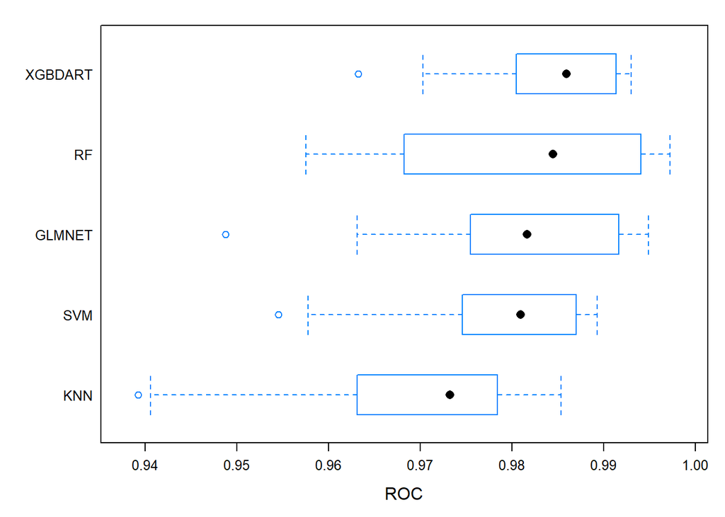

```r
scales <- list(x=list(relation="free"), y=list(relation="free"))
bwplot(model_compare, scales=scales,metric = "ROC")
```

Berdasarkan boxplot diatas, didapatkan bahwa model yang paling bagus performanya adalah XGBDart.